# Modelling complex spectral data with the resemble package

Leonardo Ramirez-Lopez and Alexandre M.J.-C. Wadoux

ramirez.lopez.leo@gmail.com

2020-10-29

Think Globally, Fit Locally (Saul and Roweis 2003)

[figure not shown]

# 1 Introduction

Modeling spectral data has garnered wide interest in the last four decades. Spectroscopy is the study of the spectral response of a matrix (e.g. soil, plant material, seeds, etc.) when it interacts with electromagnetic radiation. This spectral response directly or indirectly relates to a wide range of compositional characteristics (chemical, physical or biological) of the matrix. Therefore, it is possible to develop empirical models that can accurately quantify properties of different matrices. In this respect, quantitative spectroscopy techniques are usually fast, non-destructive and cost-efficient in comparison to conventional laboratory methods used in the analyses of such matrices. This has resulted in the development of comprehensive spectral databases for several agricultural products comprising large amounts of observations. The size of such databases increases *de facto* their complexity. To analyze large and complex spectral data, one must then resort to numerical and statistical tools and methods such as dimensionality reduction, and local spectroscopic modeling based on spectral dissimilarity concepts.

The aim of the `resemble` package is to provide tools to efficiently and accurately extract meaningful quantitative information from large and complex spectral databases. The core functionalities of the package include:

- dimensionality reduction
- computation of dissimilarity measures
- evaluation of dissimilarity matrices
- spectral neighbour search
- fitting and predicting local spectroscopic models

# 2 Citing the package

Simply type and you will get the info you need:

```r
citation(package = "resemble")
```

```
##
##
##   Ramirez-Lopez, L., and Stevens, A., and Viscarra Rossel, R., and
##   Lobsey, C., and Wadoux, A., and Breure, T. (2020). resemble:
##   Regression and similarity evaluation for memory-based learning in
##   spectral chemometrics. R package Vignette R package version 2.0.0.
##
## A BibTeX entry for LaTeX users is
##
##   @Manual{,
##     title = {resemble: Regression and similarity evaluation for memory-based learning in spectral chemometrics. },
##     author = {Leonardo Ramirez-Lopez and Antoine Stevens and Raphael Viscarra Rossel and Craig Lobsey and Alex Wadoux and Timo Breure},
##     publication = {R package Vignette},
##     year = {2020},
##     note = {R package version 2.0.0},
##     url = {https://CRAN.R-project.org/package=resemble},
##   }
```

# 3 Example dataset

This vignette uses the soil Near-Infrared (NIR) spectral dataset provided in the [package `prospectr`](https://CRAN.R-project.org/package=prospectr) package (Stevens and Ramirez-Lopez 2020). The reason why we use this dataset is because soils are one of the most complex matrices analyzed with NIR spectroscopy. This spectral dataset/library was used in the challenge by Pierna and Dardenne (2008). The library contains NIR absorbance spectra of dried and sieved 825 soil observations/samples. These samples originate from agricultural fields collected from all over the Walloon region in Belgium. The data are in an `R` `data.frame` object which is organized as follows:

- **Response variables**:
  - *Nt* (Total Nitrogen in g/kg of dry soil): a numerical variable (values are available for 645 samples and missing for 180 samples).
  - *Ciso* (Carbon in g/100 g of dry soil): a numerical variable (values are available for 732 and missing for 93 samples).
  - *CEC* (Cation Exchange Capacity in meq/100 g of dry soil): A numerical variable (values are available for 447 and missing for 378 samples).
- **Predictor variables**: the predictor variables are in a matrix embedded in the data frame, which can be accessed via `NIRsoil$spc`. These variables contain the NIR absorbance spectra of the samples recorded between the 1100 nm and 2498 nm of the electromagnetic spectrum at 2 nm interval. Each column name in the matrix of spectra represents a specific wavelength (in nm).
- **Set**: a binary variable that indicates whether the samples belong to the training subset (represented by 1, 618 samples) or to the test subset (represented by 0, 207 samples).

Load the necessary packages and data:

```r
library(resemble)
library(prospectr)
library(magrittr)
```

The dataset can be loaded into R as follows:

```r
data(NIRsoil)
dim(NIRsoil)
str(NIRsoil)
```

# 4 Spectra pre-processing

This step aims at improving the signal quality of the spectra for quantitative analysis. In this respect, the following standard methods are applied using the [package `prospectr`](https://CRAN.R-project.org/package=prospectr) (Stevens and Ramirez-Lopez 2020):

1. Resampling from a resolution of 2 nm to a resolution of 5 nm.
2. First derivative using Savitsky-Golay filtering (Savitzky and Golay 1964).

```r
# obtain a numeric vector of the wavelengths at which spectra is recorded
wavs <- NIRsoil$spc %>% colnames() %>% as.numeric()

# pre-process the spectra:
# - resample it to a resolution of 6 nm
# - use first order derivative
new_res <- 5
poly_order <- 1
window <- 5
diff_order <- 1

NIRsoil$spc_p <- NIRsoil$spc %>%
  resample(wav = wavs, new.wav = seq(min(wavs), max(wavs), by = new_res)) %>%
  savitzkyGolay(p = poly_order, w = window, m = diff_order)
```

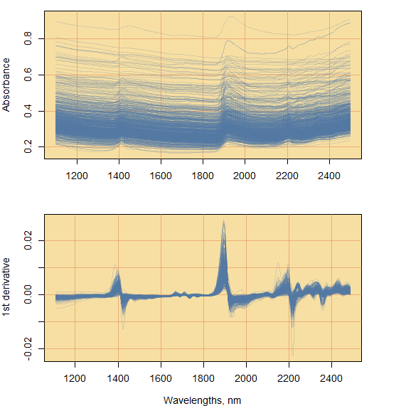

Figure 4.1: Raw spectral absorbance data (top) and first derivative of the absorbance spectra (bottom).

```r
new_wavs <- as.matrix(as.numeric(colnames(NIRsoil$spc_p)))

matplot(x = wavs, y = t(NIRsoil$spc),
        xlab = "Wavelengths, nm",
        ylab = "Absorbance",
        type = "l", lty = 1, col = "#5177A133")

matplot(x = new_wavs, y = t(NIRsoil$spc_p),
        xlab = "Wavelengths, nm",
        ylab = "1st derivative",
        type = "l", lty = 1, col = "#5177A133")
```

Both the raw absorbance spectra and the first derivative spectra are shown in Figure 4.1. The first derivative spectra represents the explanatory variables that will be used for all the examples throughout this document.

For more explicit examples, the `NIRsoil` data is split into training and testing subsets:

```r
# training dataset
training  <- NIRsoil[NIRsoil$train == 1, ]
# testing dataset
testing  <- NIRsoil[NIRsoil$train == 0, ]
```

In the resemble package we use the following notation (L. Ramirez-Lopez, Behrens, Schmidt, Stevens, et al. (2013)):

- **Training observations**:
  - `Xr` stands for the matrix of predictor variables in the reference/training set (spectral data for calibration).
  - `Yr` stands for the response variable(s) in the reference/training set (dependent variable for calibration). In the context of this package, `Yr` is also referred as to “*side information*”, which is a variable or set of variables that are associated to the training observations that can also be used to support or guide optimization during modeling, but that not necessarily are part of the input of such models. For example, we will see in latter sections that `Yr` can be used in Principal Component Analysis to help on deciding how many components are optimal.
- **Testing observations**:
  - `Xu` stands for the matrix of predictor variables in the unknown/test set (spectral data for validation/testing).
  - `Yu` stands for the response variable(s) in the unknown/test set (dependent variable for testing).

# 5 Dimensionality reduction

When conducting exploratory analysis of spectral data, we face the curse of dimensionality. It is such that we may be dealing with (using NIR spectra data as an example) hundreds to thousands of individual wavelengths for each spectrum. When one wants to find patterns in the data, spectral similarities and differences, or detect spectral outliers, it is necessary to reduce the dimension of the spectra while retaining important information.

Principal Component (PC) analysis and Partial Least Squares (PLS) decomposition methods assume that the meaningful structure the data intrinsically lies on a lower dimensional space. Both methods attempt to find a projection matrix that projects the original variables onto a less complex space represented by new few variables. These new variables mimic the original variability across observations. These two methods can be considered as the standard ones for dimensionality reduction in many fields of spectroscopic analysis.

The difference between PC and PLS is that in PC the objective is to find few new variables (which are orthogonal) that capture as much of the original data variance while in the latter the objective is to find few new variables that maximize their variance with respect to a set of one or more external variables (e.g. response variables or side information variables).

## 5.1 Methods

In the `resemble` package, PC analysis and PLS decomposition are available through the `ortho_projection()` function which offers the following algorithms:

- `"pca"`: the standard method for PC analysis based on the singular value decomposition algorithm.
- `"pca.nipals"`: this algorithm uses the non-linear iterative partial least squares algorithm (NIPALS, Wold 1975) for the purpose of PC analysis.
- `"pls"`: Here, PLS decomposition also uses the NIPALS algorithm, but in this case it makes use of *side information*, which can be a variable or set of variables that are **associated to the training observations** and that are used to project the data. In this case, the variance between the projected variables and the *side information* variable(s) is maximized.

The PC analysis of the training spectra can be executed as follows:

```r
# principal component (pc) analysis with the default
# method (singular value decomposition)
pca_tr <- ortho_projection(Xr = training$spc_p, method = "pca")

pca_tr
```

Plot the `ortho_projection` object:

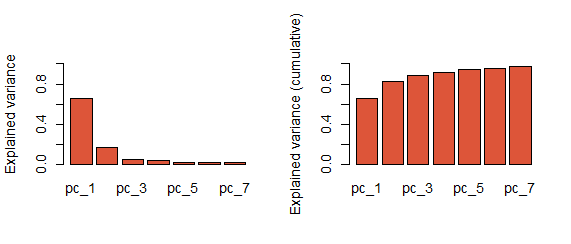

Figure 5.1: Individual contribution to the explained variance for each component (left) and cumulative variance explained by the principal components (right).

```r
plot(pca_tr, col = "#D42B08CC")
```

The code above shows that in this dataset, 7 components are required to explain around 97% of the original variance found in the spectra (Figure 5.1).

Equivalent results can be obtained with the NIPALS algorithm:

```r
# principal component (pc) analysis with the default
# NIPALS algorithm
pca_nipals_tr <- ortho_projection(Xr = training$spc_p,
                                  method = "pca.nipals")

pca_nipals_tr
```

The advantage of the NIPALS algorithm is that it can be faster than SVD when only few components are required.

For a PLS decomposition the `method` argument is set to `"pls"`. In this case, side information (`Yr`) is required. In the following example, the side information used is the Total Carbon (`Ciso`):

```r
# Partial Least Squares decomposition using
# Total carbon as side information
# (this might take some seconds)
pls_tr <- ortho_projection(Xr = training$spc_p,
                           Yr = training$Ciso,
                           method = "pls")
pls_tr
```

Note that in the previous code, for PLS projection the observations with missing `training$Ciso` are hold out, and then the projection takes place. The missing observations are projected with the resulting projection matrix and pooled together with the initial results.

By default the `ortho_projection()` function retains all the first components that, alone, account for at least 1% of the original variance of data. In the following section we will see that the function also offers additional options that might be more convenient for choosing the number of components.

## 5.2 Selection of the components/dimensions

Those options can be specified using the `pc_selection` argument. The following options are all the ones available for that purpose:

### 5.2.1 *Single component explained variance-based selection*, `"var"` (default option):

Those components that alone explain more than a given amount of the original spectral variance are retained. Example:

```r
# This retains components that alone explain at least 5% of the original
# variation in training$spc_p
var_sel <-  list(method = "var", value = 0.05)
pca_tr_minvar5 <- ortho_projection(Xr = training$spc_p,
                                   method = "pca",
                                   pc_selection = var_sel)

pca_tr_minvar5
```

### 5.2.2 *Cumulative variance-based selection*, `"cumvar"`:

Only the first components that together explain at least a given amount of the original variance are retained. Example:

```r
# This retains components that together explain at least 90% of the original
# variation in training$spc_p
cumvar_sel <-  list(method = "cumvar", value = 0.90)

pca_tr_cumvar90 <- ortho_projection(Xr = training$spc_p,
                                    method = "pca",
                                    pc_selection = cumvar_sel)

pca_tr_cumvar90
```

### 5.2.3 *Optimal component selection* `"opc"`:

This is a more sophisticated method in which the selection of the components is based on the side information concept presented in L. Ramirez-Lopez, Behrens, Schmidt, Stevens, et al. (2013). First let $P$ be a sequence of retained components (so that $P = 1, 2, ...,k$). At each iteration, the function computes a dissimilarity matrix retaining $p_i$ components. The values in this side information variable are compared against the side information values of their most spectrally similar observations. The optimal number of components retrieved by the function is the one that minimizes the root mean squared differences (RMSD) in the case of continuous variables, or maximizes the kappa index in the case of categorical variables. The RMSD is calucated as follows:

$$\begin{equation}
j(i) = NN(xr_i, Xr^{\{-i\}})
\end{equation}$$

$$\begin{equation}
RMSD = \sqrt{\frac{1}{m} \sum_{i=1}^m {(y_i - y_{j(i)})^2}}
\end{equation}$$

where $j(i) = NN(xr_i, Xr^{\{-i\}})$ represents a function to obtain the index of the nearest neighbor observation found in $Xr$ (excluding the $i$th observation) for $xr_i$, $y_i$ is the value of the side variable of the $i$th observation, $y_{j(i)}$ is the value of the side variable of the nearest neighbor of the $i$th observation and $m$ is the total number of observations. Note that for the `"opc"` method `Yr` is required (i.e. the side information of the observations). Type `help(sim_eval)` in the `R` console to get more details on how the RMSD and kappa are calculated in the function.

The rationale behind the `"opc"` method is based on the assumption that the closer two observations are in terms of their explanatory variables (`Xr`), the closer they may be in terms of their side information (`Yr`).

```r
# This uses optimal component selection
# variation in training$spc_p
optimal_sel <-  list(method = "opc", value = 40)
pca_tr_opc <- ortho_projection(Xr = training$spc_p,
                               Yr = training$Ciso,
                               method = "pca",
                               pc_selection = optimal_sel)
pca_tr_opc
```

In the example above, 11 components are required to represent the space in which the overall Total Carbon difference between each sample and its corresponding nearest neighbor is minimized. The following graph shows how the RMSD varies as a function of the number of components (Figure 5.2):

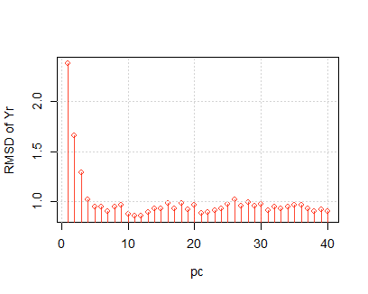

Figure 5.2: Root mean squared difference between the samples and their corresponding nearest neighbors (for Total Carbon as side finormation) found by using dissimilarity matrices computed with different number of PCs.

```r
plot(pca_tr_opc, col = "#FF1A00CC")
```

The following code exemplifies how the RMSD is calculated (only for the 11th component, Figure 5.3):

```r
# compute the dissimilarity matrix using all the retained scores
pc_diss <- f_diss(pca_tr_opc$scores, diss_method = "mahalanobis")
# get the nearest neighbor for each sample
nearest_n <- apply(pc_diss, MARGIN = 1, FUN = function(x) order(x)[2])
# compute the RMSD
rmsd <- sqrt(mean((training$Ciso - training$Ciso[nearest_n])^2, na.rm = TRUE))
rmsd
```

```
## [1] 0.8570114
```

```r
# the RSMD for all the components is already available in
# ...$opc_evaluation
pca_tr_opc$opc_evaluation[pca_tr_opc$n_components, , drop = FALSE]
```

```
##    pc   rmsd_Yr
## 11 11 0.8570114
```

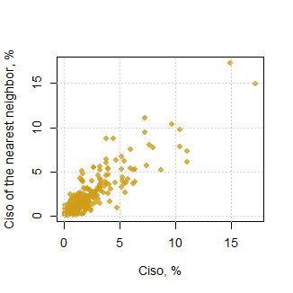

Figure 5.3: Comparison between each sample and its corresponding nearest neighbor (in terms of Total Carbon) when 11 are used for dissimilarity matrix computations.

```r
plot(training$Ciso[nearest_n],
     training$Ciso,
     ylab = "Ciso of the nearest neighbor, %", xlab = "Ciso, %",
     col = "#D19C17CC", pch = 16)
grid()
```

### 5.2.4 *Manual selection*, `"manual"`:

The user explicitly defines how many components to retrieve. Example:

```r
# This uses manual component selection
manual_sel <-  list(method = "manual", value = 9)
# PC
pca_tr_manual <- ortho_projection(Xr = training$spc_p,
                                  method = "pca",
                                  pc_selection = manual_sel)
pca_tr_manual

# PLS
pls_tr_manual <- ortho_projection(Xr = training$spc_p,
                                  Yr = training$Ciso,
                                  method = "pls",
                                  pc_selection = manual_sel)
pls_tr_manual
```

## 5.3 Using projection/dimension reduction models on new data

Both PC and PLS methods generate projection matrices that can be used to project new observations onto the new lower dimensional score space they were built for. In the case of PC analysis this projection matrix is equivalent to the transposed matrix of loadings. The `predict` method along with a projection model can be used to project new data:

```r
optimal_sel <-  list(method = "opc", value = 40)
# PLS
pls_tr_opc <- ortho_projection(Xr = training$spc_p,
                               Yr = training$Ciso,
                               method = "pls",
                               pc_selection = optimal_sel,
                               scale = TRUE)
# the pls projection matrix
pls_tr_opc$projection_mat

pls_projected <- predict(pls_tr_opc, newdata = testing$spc_p)

# PC
pca_tr_opc <- ortho_projection(Xr = training$spc_p,
                               Yr = training$Ciso,
                               method = "pca",
                               pc_selection = optimal_sel,
                               scale = TRUE)
# the pca projection matrix
t(pca_tr_opc$X_loadings)

pca_projected <- predict(pca_tr_opc, newdata = testing$spc_p)
```

## 5.4 Projecting two separate datasets in one single run

The `ortho_projection()`function allows to project two separate datasets in one run. For example, training and testing data can be passed to the function as follows:

```r
optimal_sel <-  list(method = "opc", value = 40)
pca_tr_ts <- ortho_projection(Xr = training$spc_p,
                              Xu = testing$spc_p,
                              Yr = training$Ciso,
                              method = "pca",
                              pc_selection = optimal_sel,
                              scale = TRUE)
plot(pca_tr_ts)
```

In the above code for PC analyisis, `training` and `testing` datasets are pooled together and then projected and split back for presenting the final results. For the `opc` selection method, the dissimilarity matrices are built only for the `training` data and for the observations with available side information (Total Carbon). These dissimilarity matrices are used only to find the optimal number of PCs. Note that `Xr` and `Yr` refer to the same observations. Also note that the optimal number of PCs might not be the same as when `testing` is not passed to the `Xu` argument since the PC projection model is built from a different pool of observations.

In the case of PLS, the observations used for projection necessarily have to have side information available, therefore the missing values in `Yr` are hold out during the projection model building. For these samples, the final projection matrix is use to project them into the PLS space.

```r
optimal_sel <-  list(method = "opc", value = 40)
pls_tr_ts <- ortho_projection(Xr = training$spc_p,
                              Xu = testing$spc_p,
                              Yr = training$Ciso,
                              method = "pls",
                              pc_selection = optimal_sel,
                              scale = TRUE)

# the same PLS projection model can be obtained with:
pls_tr_ts2 <- ortho_projection(Xr = training$spc_p[!is.na(training$Ciso),],
                               Yr = training$Ciso[!is.na(training$Ciso)],
                               method = "pls",
                               pc_selection = optimal_sel,
                               scale = TRUE)

identical(pls_tr_ts$projection_mat, pls_tr_ts2$projection_mat)
```

## 5.5 Using more than one variable as side information

The `ortho_projection()`function allows to pass more than one variable to `Yr` (side information):

```r
optimal_sel <-  list(method = "opc", value = 40)
pls_multi_yr <- ortho_projection(Xr = training$spc_p,
                                 Xu = testing$spc_p,
                                 Yr = training[, c("Ciso", "Nt", "CEC")],
                                 method = "pls",
                                 pc_selection = optimal_sel,
                                 scale = TRUE)
plot(pls_multi_yr)
```

In the above code for PLS projections using multivariate side information, the PLS2 method (based on the NIPALS algorithm) is used (see Wold et al. 1983). The optimal component selection (`opc`) also uses the multiple variables passed to `Yr`, the RMSD is computed for each of the variables. Each RMSD is then standardized and the final RMSD used for optimization is their average. For the example above, this data can be accessed as follows:

```r
pls_multi_yr$opc_evaluation
```

For PC analysis multivariate side information is also allowed for the `opc` method. Alternatively, a categorical variable can also be used as side information for the `opc`. In that case, the kappa index is used instead of the RMSD.

# 6 Computing dissimilarity matrices

Similarity/dissimilarity measures between objects are often estimated by means of distance measurements, the closer two objects are to one another, the higher the similarity between them. Dissimilarity or distance measures are useful for a number of applications, for example for outlier detection and nearest neighbors search.

The `dissimilarity()` function is the main function for measuring dissimilarities between observations. It is basically a wrapper to other existing dissimilarity functions within the package (see `f_diss()`, `cor_diss()`, `sid()` and `ortho_diss()`). It allows to compute dissimilarities between:

- all the observations in a single matrix.
- observations in a matrix against observations in a second matrix.

The dissimilarity methods available in `dissimilarity()` are as follows (see `diss_method` argument):

- `"pca"`: Mahalanobis distance computed on the matrix of scores of a PC projection of `Xr` (and `Xu` if provided). PC projection is done using the singular value decomposition (SVD) algorithm. Type `help(ortho_diss)` for more details on the function called by this method.
- `"pca.nipals"`: Mahalanobis distance computed on the matrix of scores of a PC projection of `Xr` (and `Xu` if provided). PC projection is done using the non-linear iterative partial least squares (NIPALS) algorithm. Type `help(ortho_diss)` in the `R` console for more details on the function called by this method.
- `"pls"`: Mahalanobis distance computed on the matrix of scores of a partial least squares projection of `Xr` (and `Xu` if provided). In this case, `Yr` is always required. Type `help(ortho_diss)` in the `R` console for more details on the function called by this method.
- `"cor"`: correlation dissimilarity which is based on the coefficient between observations. Type `help(cor_diss)` in the `R` console for more details on the function called by this method.
- `"euclid"`: Euclidean distance between observations. Type `help(f_diss)` in the `R` console for more details on the function called by this method.
- `"cosine"`: Cosine distance between observations. Type `help(f_diss)` in the `R` console for more details on the function called by this method.
- `"sid"`: spectral information divergence between observations. Type `help(sid)` in the `R` console for more details on the function called by this method.

## 6.1 Dissimilarity measured on orthogonal spaces

In this package, the orthogonal space dissimilarities refer to dissimilarity measures performed either in the PC space or in the PLS space.

Since we can assume that the meaningful structure the data lies on a lower dimensional space, we can also assume that this lower dimensional space is optimal to measure the dissimilarity between observations (L. Ramirez-Lopez, Behrens, Schmidt, Viscarra-Rossel, et al. 2013).

To measure the dissimilarity between observations ($x_i$ and $x_j$), the Mahalanobis distance is computed on their corresponding projected score vectors ($t_i$ and $t_j$) found in the matrix of scores ($\mathrm T$):

$$d(x_i,x_j) = d(t_i,t_j) = \sqrt{\frac{1}{z}\sum(t_i - t_j) C^{-1}(t_i - t_j)'}$$
where $z$ is the number of components used, $C^{-1}$ is the inverse of the covariance matrix computed from the matrix of projected variables for all the observations $\mathrm T$. Since the projected variables are orthogonal to each other, the resulting $C^{-1}$ would be equivalent to a diagonal matrix with the variance of each $\mathrm T$ column in its main diagonal. Therefore, for this case of orthogonal spaces, the Mahalanobis distance is equivalent to the Euclidean distance applied on the variance-scaled $\mathrm T$ (De Maesschalck, Jouan-Rimbaud, and Massart 2000).

To compute orthogonal dissimilarities in the `resemble` package, the `dissimilarity()` function can be used as follows:

```r
# for PC dissimilarity using the default settings
pcd <- dissimilarity(Xr = training$spc_p,
                     diss_method = "pca")
dim(pcd$dissimilarity)

# for PC dissimilarity using the optimized component selection method
pcd2 <- dissimilarity(Xr = training$spc_p,
                      diss_method = "pca.nipals",
                      Yr = training$Ciso,
                      pc_selection = list("opc", 20),
                      return_projection = TRUE)
dim(pcd2$dissimilarity)
pcd2$dissimilarity
pcd2$projection # the projection used to compute the dissimilarity matrix

# for PLS dissimilarity
plsd <- dissimilarity(Xr = training$spc_p,
                      diss_method = "pls",
                      Yr = training$Ciso,
                      pc_selection = list("opc", 20),
                      return_projection = TRUE)
dim(plsd$dissimilarity)
plsd$dissimilarity
plsd$projection # the projection used to compute the dissimilarity matrix
```

```r
# For PC dissimilarity using the optimized component selection method
pcd_tr_ts <- dissimilarity(Xr = training$spc_p,
                           Xu = testing$spc_p,
                           diss_method = "pca.nipals",
                           Yr = training$Ciso,
                           pc_selection = list("opc", 20))
dim(pcd_tr_ts$dissimilarity)

# For PLS dissimilarity
plsd_tr_ts <- dissimilarity(Xr = training$spc_p,
                            Xu = testing$spc_p,
                            diss_method = "pls",
                            Yr = training$Ciso,
                            pc_selection = list("opc", 20))
dim(plsd_tr_ts$dissimilarity)
```

In the last two examples, matrices of 618 rows and 207 columns are retrieved. The number of rows is the same as in the training dataset while the number of columns is the same as in the testing dataset. The dissimilarity between the $i$th observation in the training dataset and the $j$th observation in the testing dataset is stored in the $i$th row and the $j$th column of the resulting dissimilarity matrices.

### 6.1.1 Combine k-nearest neighbors and dissimilarity measures in the orthogonal space

It is also possible to measure the dissimilarity between observations in a localized fashion. In this case, first a global dissimilarity matrix is computed. Then, by using this matrix for each target observation, a given set of k-nearest neighbors are identified. These neighbors (together with the target observation) are projected (from the original data space) onto a (local) orthogonal space (using the same parameters specified in the function). In this projected space the Mahalanobis distance between the target observation and its neighbors is recomputed. A missing value is assigned to the observations that do not belong to this set of neighbors (non-neighbor observations). In this case the dissimilarity matrix cannot be considered as a distance metric since it does not necessarily satisfies the symmetry condition for distance matrices (i.e. given two observations $x_i$ and $x_j$, the local dissimilarity, $d$, between them is relative since generally $d(x_i, x_j) \neq d(x_j, x_i)$).

For computing this type of localized dissimilarity matrix, two arguments need to be passed to the `dissimilarity()` function: `.local` and `pre_k`. These are not formal arguments of the function, however, they are passed to the `ortho_diss()`function which is used by the `dissimilarity()` function for computing the dissimilarities in the orthogonal spaces.

Here are two examples on how to perform localized dissimilarity computations:

```r
# for localized PC dissimilarity using the optimized component selection method
# set the number of neighbors to retain
knn <- 200
local_pcd_tr_ts <- dissimilarity(Xr = training$spc_p,
                                 Xu = testing$spc_p,
                                 diss_method = "pca",
                                 Yr = training$Ciso,
                                 pc_selection = list("opc", 20),
                                 .local = TRUE,
                                 pre_k = knn)
## The neighborhoods of 207 observations contain missing 'Yr' values.
## Check ...$neighborhood_info
dim(local_pcd_tr_ts$dissimilarity)
```

```
## [1] 618 207
```

```r
# For PLS dissimilarity
local_plsd_tr_ts <- dissimilarity(Xr = training$spc_p,
                                  Xu = testing$spc_p,
                                  diss_method = "pls",
                                  Yr = training$Ciso,
                                  pc_selection = list("opc", 20),
                                  .local = TRUE,
                                  pre_k = knn)
## The neighborhoods of 207 observations contain missing 'Yr' values.
## Check ...$neighborhood_info
dim(local_plsd_tr_ts$dissimilarity)
```

```
## [1] 618 207
```

```r
# check the dissimilarity scores between the first two
# observations in the testing dataset and the first 10
# observations in the training dataset
local_plsd_tr_ts$dissimilarity[1:10, 1:2]
```

```
##       Xu_1      Xu_2
## Xr_1          *         *
## Xr_2  1.9537271 2.0093944
## Xr_3  2.0663499         *
## Xr_4  2.3116881 1.6281155
## Xr_5          *         *
## Xr_6          * 1.8760568
## Xr_7  2.1609596 2.0513451
## Xr_8  2.1993001 1.8352469
## Xr_9  2.1764284 2.0324282
## Xr_10         *         *
## *: not a neighbor
```

## 6.2 Correlation dissimilarity

$$d(x_i, x_j) = \frac{1}{2} (1 - \rho(x_i, x_j))$$

Note that $d$ cannot be considered as a distance metric since it does not satisfy the axiom of identity of indiscernibles. Therefore we prefer the use of the term dissimilarity.

The following code demonstrates how to compute the correlation dissimilarity between all observations in the training dataset:

```r
cd_tr <- dissimilarity(Xr = training$spc_p, diss_method = "cor")
dim(cd_tr$dissimilarity)
cd_tr$dissimilarity
```

To compute the correlation dissimilarity between training and testing observations:

```r
cd_tr_ts <- dissimilarity(Xr = training$spc_p,
                          Xu = testing$spc_p,
                          diss_method = "cor")
dim(cd_tr_ts$dissimilarity)
cd_tr_ts$dissimilarity
```

Alternatively, the correlation dissimilarity can be computed using a moving window. In this respect, a window size term $w$ is introduced to the original equation:

$$d(x_i, x_j; w) = \frac{1}{2 w}\sum_{k=1}^{p-w}1 - \rho(x_{i,\{k:k+w\}}, x_{j,\{k:k+w\}})$$

In this case, the correlation dissimilarity is computed by averaging the moving window correlation measures. The introduction of the window term increases the computational cost in comparison to the simple correlation dissimilarity. The moving window correlation dissimilarity can be computed by setting the `diss_method` argument to `"cor"` and passing a window size value to the `ws` argument as follows:

```r
# a moving window correlation dissimilarity between training and testing
# using a window size of 19 spectral data points (equivalent to 95 nm)
cd_mw <- dissimilarity(Xr = training$spc_p,
                       Xu = testing$spc_p,
                       diss_method = "cor",
                       ws = 19)
cd_mw$dissimilarity
```

## 6.3 Euclidean dissimilarity

In the computation of the Euclidean dissimilarity, each feature has equal significance. Hence, correlated variables which may represent irrelevant features, may have a disproportional influence on the final dissimilarity measurement (Brereton 2003). Therefore, it is not recommended to use this measure directly on the raw data. To compute the dissimilarity between two observations/vectors $x_i$ and $x_j$ the package uses the following equation:

$$d(x_i,x_j) = \sqrt{\frac{1}{p} \sum(x_i - x_j) (x_i - x_j)'}$$
where $p$ represents the number of variables.

With the `dissimilarity()` function the Euclidean dissimilarity can be computed as follows:

```r
# compute the dissimilarity between all the training observations
ed <- dissimilarity(Xr = training$spc_p, diss_method = "euclid")
ed$dissimilarity
```

The `dist()` function in the `R` package `stats` can also be used to compute Euclidean distances, however the `resemble` implementation tends to be faster (especially for very large matrices):

```r
# compute the dissimilarity between all the training observations
pre_time_resemble <- proc.time()
ed_resemble <- dissimilarity(Xr = training$spc_p, diss_method = "euclid")
post_time_resemble <- proc.time()
post_time_resemble - pre_time_resemble

pre_time_stats <- proc.time()
ed_stats <- dist(training$spc_p, method = "euclid")
post_time_stats <- proc.time()
post_time_stats - pre_time_stats

# scale the results of dist() based on the number of input columns
ed_stats_tr <- sqrt((as.matrix(ed_stats)^2)/ncol(training$spc_p))
ed_stats_tr[1:2, 1:3]

# compare resemble and R stats results of Euclidean distances
ed_resemble$dissimilarity[1:2, 1:3]
```

In the above code it can be seen that the results of the `dist()` require scaling based on the number of input variables. This means that, by default, the values output by `dist()` increase with the number of input variables. This is an effect that is already accounted for in the implementation of the Euclidean (and also Mahalanobis) dissimilarity implementation of `resemble`.

Another advantage of the Euclidean dissimilarity in `resemble` over the one in `R` `stats` is that the one in `resemble` allows the computation of the dissimilarities between observations in two matrices:

```r
# compute the dissimilarity between the training and testing observations
ed_tr_ts <- dissimilarity(Xr = training$spc_p,
                          Xu = testing$spc_p,
                          diss_method = "euclid")
```

## 6.4 Cosine dissimilarity

This dissimilarity metric is also known as the “Spectral Angle Mapper” which has been extensively applied in remote sensing as a tool for unsupervised classification and spectral similarity analysis. The cosine dissimilarity between two observations ($x_i$ and $x_j$) is calculated as:

$$d (x_i, x_j) = cos^{-1} \tfrac{\sum_{k=1}^{p} x_{i,k} x_{j,k} } {\sqrt{\sum_{k=1}^{p} x_{i,k}^2} \sqrt{\sum_{k=1}^{p} x_{j,k}^2}}$$
where $p$ is the number of variables.

With the `dissimilarity()` function the Euclidean dissimilarity can be computed as follows:

```r
# compute the dissimilarity between the training and testing observations
cosine_tr_ts <- dissimilarity(Xr = training$spc_p,
                              Xu = testing$spc_p,
                              diss_method = "cosine")
dim(cosine_tr_ts$dissimilarity)
cosine_tr_ts$dissimilarity
```

## 6.5 Spectral information divergence

The spectral information divergence (SID, Chang 2000) indicates how dissimilar are two observations based on their probability distributions. To account for the discrepancy between the distributions of two observations ($x_i$ and $x_j$), the SID method uses the Kullback-Leibler divergence ($kl$, Kullback and Leibler 1951) measure. Since the $kl$ is a non-symmetric measure, i.e. $kl (x_i, x_j) \neq kl(x_j, x_i)$, the dissimilarity between $x_i$ and $x_j$ based on this method is computed as:

$$d(x_i, x_j) = kl (x_i, x_j) + kl (x_j, x_i)$$

The following code can be used to compute the SID between the training and testing observations:

```r
sid_tr_ts <- dissimilarity(Xr = training$spc_p,
                           Xu = testing$spc_p,
                           diss_method = "sid")
dim(sid_tr_ts$dissimilarity)
sid_tr_ts$dissimilarity
```

See the `sid()` function in the `resemble` package for more details.

## 6.6 How to know if a dissimilarity method is reliable?

Usually, dissimilarity assessment is disregarded and the decision on what method to use is sometimes arbitrary. However, if the estimations of similarity/dissimilarity between observations from its predictor/explanatory variables fail to reflect the real or main similarity/dissimilarity, these estimations can be seen as useless for further analyses.

The package `resemble` offers functionality for assessing dissimilarity matrices. These assestments are based on first nearest neighbor search (1-NN). In this section, the different methods to measure dissimilarity between spectra are compared in terms of their ability to retrieve 1-NNs observations with similar Total Carbon (“Ciso”). This indicates how well the spectral similarity between observations reflect their compositional similarity.

Compute a dissimilarty matrix for `training$spc_p` using the different methods:

```r
# PC dissimilarity with default settings (variance-based
# of components)
pcad <- dissimilarity(training$spc_p, diss_method = "pca", scale = TRUE)

# PLS dissimilarity with default settings (variance-based
# of components)
plsd <- dissimilarity(training$spc_p, diss_method = "pls", Yr = training$Ciso,
                      scale = TRUE)

# PC dissimilarity with optimal selection of components
opc_sel <- list("opc", 30)
o_pcad <- dissimilarity(training$spc_p,
                        diss_method = "pca",
                        Yr = training$Ciso,
                        pc_selection = opc_sel,
                        scale = TRUE)

# PLS dissimilarity with optimal selection of components
o_plsd <- dissimilarity(training$spc_p,
                        diss_method = "pls",
                        Yr = training$Ciso,
                        pc_selection = opc_sel,
                        scale = TRUE)

# Correlation dissimilarity
cd <- dissimilarity(training$spc_p, diss_method = "cor", scale = TRUE)

# Moving window correlation dissimilarity
mcd <- dissimilarity(training$spc_p, diss_method = "cor", ws = 51, scale = TRUE)

# Euclidean dissimilarity
ed <- dissimilarity(training$spc_p, diss_method = "euclid", scale = TRUE)

# Cosine dissimilarity
cosd <- dissimilarity(training$spc_p, diss_method = "cosine", scale = TRUE)

# Spectral information divergence/dissimilarity
sinfd <- dissimilarity(training$spc_p, diss_method = "sid", scale = TRUE)
```

Use the `sim_eval()`function with each dissimilarity matrix to find the closest observation to each observation and compare them in terms of the `Ciso` variable:

```r
Ciso <- as.matrix(training$Ciso)
ev <- NULL
ev[["pcad"]] <- sim_eval(pcad$dissimilarity, side_info = Ciso)
ev[["plsd"]] <- sim_eval(plsd$dissimilarity, side_info = Ciso)
ev[["o_pcad"]] <- sim_eval(o_pcad$dissimilarity, side_info = Ciso)
ev[["o_plsd"]] <- sim_eval(o_plsd$dissimilarity, side_info = Ciso)
ev[["cd"]] <- sim_eval(cd$dissimilarity, side_info = Ciso)
ev[["mcd"]] <- sim_eval(mcd$dissimilarity, side_info = Ciso)
ev[["ed"]] <- sim_eval(ed$dissimilarity, side_info = Ciso)
ev[["cosd"]] <- sim_eval(cosd$dissimilarity, side_info = Ciso)
ev[["sinfd"]] <- sim_eval(sinfd$dissimilarity, side_info = Ciso)
```

Table 6.1 and Figure 6.1 show the results of the comparisons (for the training dataset) between the Total Carbon of the observations and the Total Carbon of their most similar samples (1-NN) according to the dissimilarity method used. In the example, the spectral dissimilarity matrices that best reflect the compositions similarity are those built with the *pls with optimized component selection* (`o_plsd`) and *pca with optimized component selection* (`o_pcad`).

```r
comparisons <- lapply(names(ev),
                      FUN = function(x, label) {
                        irmsd <- x[[label]]$eval[1]
                        ir <- x[[label]]$eval[2]
                        data.frame(Measure = label,
                                   RMSD = irmsd,
                                   r =  ir)
                      },
                      x = ev)
comparisons
```

Table 6.1: Root mean squared difference (RMSD) and correlation coefficients for between the observations and their corrresponding closest observations retrieved with the different dissimilarity methods.

| Measure | RMSD | r |
| --- | --- | --- |
| pcad | 0.85 | 0.9 |
| plsd | 0.94 | 0.86 |
| **o_pcad** | **0.8** | **0.91** |
| **o_plsd** | **0.75** | **0.91** |
| cd | 0.99 | 0.86 |
| mcd | 0.92 | 0.88 |
| ed | 0.82 | 0.9 |
| cosd | 1.01 | 0.86 |
| sinfd | 1.44 | 0.72 |

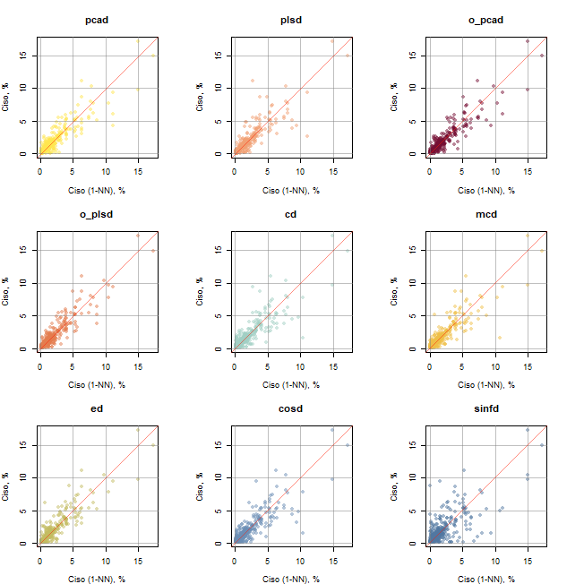

Figure 6.1: Comparison between observations and their corresponding nearest neighbor (1-NN) observation in terms of Tocal Carbon (Ciso). The 1-NNs are retrieved with the following dissimilarity merics: pcad: PC dissimilarity with default settings (variance-based of components); plsd: PLS dissimilarity with default settings (variance-based of components); o_pcad: PC dissimilarity with optimal selection of components; o_plsd: PLS dissimilarity with optimal selection of components; cd: Correlation dissimilarity; mcd: Moving window correlation dissimilarity; ed: Euclidean dissimilarity; sinfd: Spectral information divergence/dissimilarity.

```r
old_par <- par("mfrow")
par(mfrow = c(3, 3))
p <- sapply(names(ev),
            FUN = function(x, label, labs = c("Ciso (1-NN), %", "Ciso, %")) {
              xy <- x[[label]]$first_nn[,2:1]
              plot(xy, xlab = labs[1], ylab = labs[2], col = "red")
              title(label)
              grid()
              abline(0, 1)

            },
            x = ev)
par(old_par)
```

# 7 k-Nearest Neighbors (k-NN) search

In the package, the k-NN search aims at finding in a given reference set of observations a group of spectrally similar observations for another given set of observations. For an observation, its most similar observations are known as nearest neighbors and they are usually found by using dissimilairty metrics.

In `resemble`, the k-nearest neighbor search is implemented in the function `search_neighbors()`. This function uses the `dissimilarity()` function to compute the dissimilarity matrix that serves in the identification of the neighbors. These neighbors can be retained in two ways: *i*. by providing a specific number of neighbors or *ii*. by setting a dissimilarity threshold ($d_{th}$).

We encourage readers to go through the section where we discuss about dissimilarity measures, which serves as the basis for the examples presented in this section.

## 7.1 Using a specific number of neighbors

This means that the neighboring observations are retained regardless their dissimilarity/distance to the target observation. Each target observation for which its neighbors are to be found ends up with the same neighborhood size ($k$). A drawback of this approach is that observations that are in fact largely dissimilar to the target observation might end up in its neighborhood. This is because the requirement for building the neighborhood is based on its size and not on the similarity of the retained observations to the target one. In the `dissimilarity()` function, the neighborhood size is controlled by the argument `k`.

Here is an example that demonstrates how `search_neighbors` can be used to search in the `training` set the spectral neighbors of the `testing` set:

```r
knn_pc <- search_neighbors(Xr = training$spc_p,
                           Xu = testing$spc_p,
                           diss_method = "pca.nipals",
                           k = 50)

# matrix of neighbors
knn_pc$neighbors

# matrix of neighbor distances (dissimilarity scores)
knn_pc$neighbors_diss

# the index (in the training set) of the first two closest neighbors found in
# training for the first observation in testing:
knn_pc$neighbors[1:2, 1, drop = FALSE]

# the distances of the two closest neighbors found in
# training for the first observation in testing:
knn_pc$neighbors_diss[1:2, 1, drop = FALSE]

# the indices in training that fall in any of the
# neighborhoods of testing
knn_pc$unique_neighbors
```

In the above code, `knn_pc$neighbors` is a matrix showing the results of the neighbors found. This is a matrix of neighbor indices where every column represents an observarion in the testing set while every row represents the neighbor index (in descending order). Every entry represents the index of the neighbor observation in the training set. The `knn_pc$neighbors_diss` matrix shows the dissimilarity scores corresponding to the neighbors found. For example, for the first observation in `testing` its closest observation found in `training` corresponds to the one with index 526 (`knn_pc$neighbors[1]`) which has a dissimilarity score of 3.57 (`knn_pc$neighbors_diss[1]`).

Neighbor search can also be conducted with all the dissimilarity measures described in previous sections. The neighbors retrieved will then depend on the dissimilarity method used. Thus, it is recommended to evaluate carefully what dissimilarity metric to use before neighbor search.

Here are other examples of neighbor search based on other dissimilarity measures:

```r
# using PC dissimilarity with optimal selection of components
knn_opc <- search_neighbors(Xr = training$spc_p,
                            Xu = testing$spc_p,
                            diss_method = "pca.nipals",
                            Yr = training$Ciso,
                            k = 50,
                            pc_selection = list("opc", 20),
                            scale = TRUE)

# using PLS dissimilarity with optimal selection of components
knn_pls <- search_neighbors(Xr = training$spc_p,
                            Xu = testing$spc_p,
                            diss_method = "pls",
                            Yr = training$Ciso,
                            k = 50,
                            pc_selection = list("opc", 20),
                            scale = TRUE)

# using correlation dissimilarity
knn_c <- search_neighbors(Xr = training$spc_p,
                          Xu = testing$spc_p,
                          diss_method = "cor",
                          k = 50, scale = TRUE)

# using moving window correlation dissimilarity
knn_mwc <- search_neighbors(Xr = training$spc_p,
                            Xu = testing$spc_p,
                            diss_method = "cor",
                            k = 50,
                            ws = 51, scale = TRUE)
```

Another example with localized PC and PLS dissimilarity measures:

```r
# using localized PC dissimilarity with optimal selection of components
knn_local_opc <- search_neighbors(Xr = training$spc_p,
                                  Xu = testing$spc_p,
                                  diss_method = "pca.nipals",
                                  Yr = training$Ciso,
                                  k = 50,
                                  pc_selection = list("opc", 20),
                                  scale = TRUE,
                                  .local = TRUE,
                                  pre_k = 250)

# using localized PLS dissimilarity with optimal selection of components
knn_local_opc <- search_neighbors(Xr = training$spc_p,
                                  Xu = testing$spc_p,
                                  diss_method = "pls",
                                  Yr = training$Ciso,
                                  k = 50,
                                  pc_selection = list("opc", 20),
                                  scale = TRUE,
                                  .local = TRUE,
                                  pre_k = 250)
```

## 7.2 Using a dissimilarity threshold

Here, the neighboring observations to be retained must have a dissimilarity score less or equal to a given dissimilarity threshold ($d_{th}$). Therefore, the neighborhood size of the target observations is not constant. A drawback with this approach is that choosing a meaningful $d_{th}$ can be difficult, especially because its value is largely influenced by the dissimilarity method used. Furthermore, some neighborhoods retrieved by certain thresholds might be of a very small size or even empty, which constraints any type of analysis within such neighborhoods. On the other hand, some neighborhood might end up with large sizes which might include either redundant observations or in some other cases where $d_{th}$ is too large the complexity in the neighborhood might be large. In the `dissimilarity()` function, $d_{th}$ is controlled by the argument `k_diss`. This argument is accompanied by the argument `k_range` which is used to control the maximum and minimum neighborhood sizes. For example, if a neighborhood size is below the minimum size $k_{min}$ specified in `k_range`, the function automatically ignores $d_{th}$ and retrieves the $k_{min}$ closest observations. Similarly, if the neighborhood size is above the maximum size $k_{max}$ specified in `k_range` the function automatically ignores $d_{th}$ and retrieves only a maximum of $k_{max}$ neighbors.

In the package, we can use `search_neighbors()` to find in the `training` set the neighbors of the `testing` set which dissimilarity scores are less or equal to a user-defined threshold:

```r
# a dissimilarity threshold
d_th <- 1

# the minimum number of observations required in each neighborhood
k_min <- 20

# the maximum number of observations allowed in each neighborhood
k_max <- 300

dnn_pc <- search_neighbors(Xr = training$spc_p,
                           Xu = testing$spc_p,
                           diss_method = "pca.nipals",
                           k_diss = d_th,
                           k_range = c(k_min, k_max),
                           scale = TRUE)

# matrix of neighbors. The minimum number of indices is 20 (given by k_min)
# and the maximum number of indices is 300 (given by k_max).
# NAs indicate "not a neighbor"
dnn_pc$neighbors

# this reports how many neighbors were found for each observation in
# testing using the input distance threshold (column n_k) and how
# many were finally selected (column final_n_k)
dnn_pc$k_diss_info

# matrix of neighbor distances
dnn_pc$neighbors_diss

# the indices in training that fall in any of the
# neighborhoods of testing
dnn_pc$unique_neighbors
```

In the code above, the size of the neighborhoods is not constant, the size variability can be easily visualized with a histogram on `dnn_pc$k_diss_info$n_k`. Figure 7.1, shows that many  
neighborhoods were reset to a size of 20 or to a size of 300.

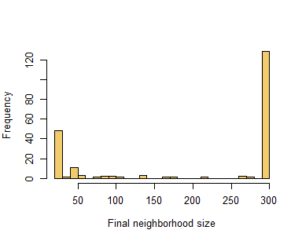

```r
hist(dnn_pc$k_diss_info$final_n_k,
     breaks = k_min,
     xlab = "Final neighborhood size",
     main = "", col = "#EFBF47CC")
```

## 7.3 *Spiking* the neighborhoods

In the package, *spiking* refers to forcing specific observations to be included in the neighborhoods. For example, if we are searching in the `training` set the neighbors of the `testing` set, and if we want to force certain observations in `training` to be included in the neighborhood of each observation in `tetsing`, we can use the `spike` argument in `search_neighbors()`. For that, in this argument we will need to pass the indices of `training` that we will be forced into the neighborhoods. The following example demonstrates how to do that: measures:

```r
# the indices of the observations that we want to "invite" to every neighborhood
forced_guests <- c(1, 5, 8, 9)

# using PC dissimilarity with optimal selection of components
knn_spiked <- search_neighbors(Xr = training$spc_p,
                               Xu = testing$spc_p,
                               diss_method = "pca.nipals",
                               Yr = training$Ciso,
                               k = 50,
                               spike = forced_guests,
                               pc_selection = list("opc", 20))

# check the first 8 neighbors found in training for the
# first 2 observations in testing
knn_spiked$neighbors[1:8, 1:2]
```

The previous code shows that the indices specified in `forced_guests` are always selected as part of every neighborhood.

Spiking might be useful when there is a prior knowledge of the similarity between certain observations that cannot be easily pick up by the data.

# 8 Regression

## 8.1 Memory-based learning

Memory-based learning (MBL) describes a family of (non-linear) machine learning methods designed to deal with complex spectral datasets (L. Ramirez-Lopez, Behrens, Schmidt, Stevens, et al. 2013). In MBL, instead of deriving a general or global regression function, a specific regression model is built for each observation requiring a prediction of a response. Each model is fitted using the nearest neighbors of the target observation found in a calibration or reference set [8.1]. While a global function may be very complex, MBL can describe the target function as a collection of less complex local (or locally stable) approximations (Mitchell 1997). For example, for predicting the response variable $Y$ of a set of $m$ observations from their explanatory variables $X$, a set of $m$ functions are required to be fitted. This can be described as:

$$\hat{y}_i = \hat{f}_i(x_i;\theta_i) + \varepsilon_{i} \; \forall \; i = \{1, ..., m\}$$
where $\theta_{i}$ represents a set of particular parameters required to fit $\hat{f}_i$ (e.g. number of factors in a PLS model), and $\varepsilon_{i}$ is a residual error term from the fitting of $\hat{y}_{i}$ in the $i$th neighborhood. Therefore, MBL in the above example can be described broadly as:

$$\hat{f} = \{\hat{f}_1,...,\hat{f}_m\}$$
Figure 8.1 illustrates the basic steps in MBL for a set of five observations ($m = 5$).

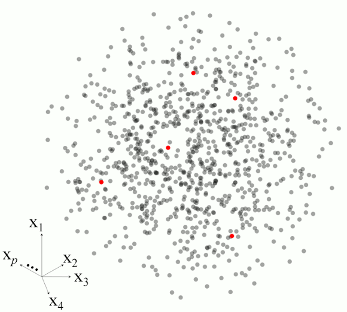

Figure 8.1: Example of the main steps in memory-based learning for predicting a response variable in five different observations based on set of p-dimensional space.

There are four basic aspects behind the steps in Figure 8.1 that must be defined for any MBL algorithm:

1. *A dissimilarity metric*: It is required for neighbor search. The dissimilarity metric used must be capable also to reflect the dissimilarity in terms of the response variable for which models are to be built. For example, in soil NIR spectroscopy, the spectral dissisimilarity values of soil samples must be capable of reflecting the compositional dissisimilarity between them. Dissimilarity methods that poorly reflect this general sample dissimilarity are prone to lead to MBL models with poor predictive performance.
2. *How many neighbors to look at?*: It is important to optimize the neighborhood size to be used for fitting the local models. Neighborhoods which are too small might be too sensitive to noise and outliers affecting the robustness of the models (L. Ramirez-Lopez, Behrens, Schmidt, Stevens, et al. 2013). Small neighborhoods might also lack of enough variance to properly capture the relationships between the predictors and the response. On the other hand, large size neighborhoods might introduce complex non-linear relationships between predictors and response which might decrease the accuracy of the models.
3. *How to use the dissimilarity information?*: The dissimilarity information can be:
   - *Ignored*, this means is only used to retrieve neighbors (e.g. the LOCAL algorithm, Shenk, Westerhaus, and Berzaghi 1997).
   - *Used to weight the training observations* according to their dissimilarity to the target observation (e.g. as in locally weighted PLS regression, Naes, Isaksson, and Kowalski 1990).
   - *Used as source of additional predictors* (L. Ramirez-Lopez, Behrens, Schmidt, Stevens, et al. 2013). In this case, the pairwise dissimilarity matrix between all the $k$ neighbors is also retrieved. This matrix of $k \times k$ dimensions is combined with the $p$ predictor variables resulting in a final matrix of predictors (for the neighborhood) of $k \times (k+p)$ dimensions. To predict the target observation, the predictors used are the $p$ spectral variables in combination to the vector of distances between the target observation and its neighbors. In some cases, this approach might lead to an increase on the predictive performance of the local models. This combined matrix of predictors can be built as follows:
     $$\begin{equation}
     \begin{bmatrix}
     0_{1,1} & d_{2,1} & ... & d_{1,k} & x_{1,k+1} & x_{1,k+2} & ...& x_{1,k+p}\\
     d_{1,2} & 0_{2,2} & ... & d_{2,k} & x_{2,k+1} & x_{2,k+2} & ...& x_{2,k+p}\\
     ... & ... & ... & ... & ... & ... & ...& ... \\
     d_{k,1} & d_{k,2} & ... & 0_{k,k} & x_{k,k+1} & x_{k,k+2} & ...& x_{k,k+p}
     \end{bmatrix}
     \end{equation}$$
     where $d_{i,j}$ represents the dissimilarity score between the $i$th neighbor and the $j$th neighbor.
4. *How to fit the local points?*: This is given by the regression method used which is usually a linear one, as the relationships between the explanatory variables and the response are usually assumed linear within the neighborhood.

In the literature MBL is sometimes referred to as local modeling, nevertheless local modeling comprises other approaches, for example, cluster–based modeling and geographical segmentation-based modeling, etc. Hence, MBL can be described as a type of local modeling (L. Ramirez-Lopez, Behrens, Schmidt, Stevens, et al. 2013).

The `mbl()` function in the `resemble` package offers the possibility to build customized memory-based learners. This can be done by choosing from different dissimilarity metrics, different methods for neighborhood size optimization, different ways of using the dissimilarity information and different regression methods for fitting the models within the neighborhoods.

We encourage readers to go through the sections corresponding to dissimilarity measures and k-Nearest Neighbors search which serve as the basis for the examples presented in this section.

The `mbl()` function can be described in regards to the four basic aspects of the MBL methods (which are described few paragraphs above):

1. *The dissimilarity metric*: this is controlled by the `diss_method` argument of the `mbl()` function. The methods available are the same as the ones described in the dissimilarity measures section.
2. *How many neighbors to look at?*: this can be defined either in the `k` or in the `k_diss` arguments of the `mbl()` function. These arguments operate in a similar fashion as their counterparts in the `search_neighbors()` function described in the k-Nearest Neighbors search section. However, in `mbl()` a vector of different neighborhood sizes can be passed to `k`, or a vector of different distance thresholds can be passed to `k_diss`. This allows to test different values in one run. Here, the `k_diss` argument is also accompanied by the argument `k_range` which is used to control the maximum and minimum neighborhood sizes.
3. *How to use the dissimilarity information*: this is controlled by the `diss_usage` argument. If `"none"` is passed, the dissimilarity information is ignored, if `"weights"` is passed, the dissimilarity information is used to weight the training observations (using a tricubic function). If `"predictors"` is passed, the dissimilarity information is used as source of additional predictors.
4. *How to fit the local points?*: This is controlled by the `method` argument. For this, a `local_fit` object (which carries the information of the regression method and its parameters) is used. There are three methods available: partial least squares (PLS) regression, weighted average partial least squares regression (WAPLS, Shenk, Westerhaus, and Berzaghi 1997) and Gaussian process regression (GPR) with dot product covariance. The following examples show how to build such `local_fit` objects:

```r
# creates an object with instructions to build PLS models
my_plsr <- local_fit_pls(pls_c = 15)
my_plsr
## Partial least squares (pls)
## Number of factors: 15

# creates an object with instructions to build WAPLS models
my_waplsr <- local_fit_wapls(min_pls_c = 3, max_pls_c = 20)
my_waplsr
## Weighted average partial least squares (wapls)
## Min. and max. number of factors: from 3 to 20

# creates an object with instructions to build GPR models
my_gpr <- local_fit_gpr()
my_gpr
## Gaussian process with linear kernel/dot product (gpr)
## Noise: 0.001
```

A function named `mbl_control()` allows to build objects that control internal validation and some optimization aspects of the `mbl()` function. In `mbl_control()` two types of validation can be specified using the `validation_type` argument:

- Leave-nearest-neighbor-out cross-validation (`"NNv"`): From the group of neighbors of each target observation, the nearest observation (i.e. the most similar observation) is excluded and then a local model is fitted using the remaining neighbors. This model is then used to predict the value of the response variable of the nearest observation. The set of predicted values in all the 1-NN observations are finally cross-validated against their corresponding reference values.
- Local leave-group-out cross-validation (`"local_cv"`): The group of neighbors of each observation to be predicted is partitioned into different equal size subsets. The model fitted with the selected calibration samples is used to predict the response values of the local validation samples and the local root mean square error is computed. This process is repeated $m$ times and the final local error is computed as the average of the local root mean square errors obtained for all the $m$ iterations. In the `mbl_control()` function $m$ is controlled by the `numbe` argument and the size of the subsets is controlled by the `p` argument which indicates the percentage of observations to be selected from the subset of nearest neighbors. The global error of the predictions is computed as the average of the local root mean square errors.

Let’s see some examples on how to build objects for controlling the validation in `mbl`.

```r
# create an object with instructions to conduct both validation types
# "NNv" "local_cv"
two_val_control <- mbl_control(validation_type = c("NNv", "local_cv"),
                               number = 10,
                               p = 0.75)
```

The object `two_val_control` stores the instructions for conducting both types of validations (`"NNv"` and `"local_cv"`). For `"local_cv"`, the number of groups is set to 10 and the percentage of neighbors to build the local calibration groups is set to 75%.

Now that we have explained the main components for the `mbl()` let’s see how the `mbl()` function can be used to predict response variables in the `testing` set by building models with the `training` set. The following MBL configuration reproduces the LOCAL algorithm (Shenk, Westerhaus, and Berzaghi 1997):

```r
# define the dissimilarity method
my_diss <- "cor"

# define the neighborhood sizes to test
my_ks <- seq(80, 200, by = 40)

# define how to use the dissimilarity information (ignore it)
ignore_diss <- "none"

# define the regression method to be used at each neighborhood
my_waplsr <- local_fit_wapls(min_pls_c = 3, max_pls_c = 20)

# for the moment use only "NNv" validation (it will be faster)
nnv_val_control <- mbl_control(validation_type = "NNv")

# predict Total Carbon
# (remove missing values)
local_ciso <- mbl(
  Xr = training$spc_p[!is.na(training$Ciso),],
  Yr = training$Ciso[!is.na(training$Ciso)],
  Xu = testing$spc_p,
  k = my_ks,
  method = my_waplsr,
  diss_method = my_diss,
  diss_usage = ignore_diss,
  control = nnv_val_control,
  scale = TRUE
)
```

Now let’s explore the `local_ciso` object:

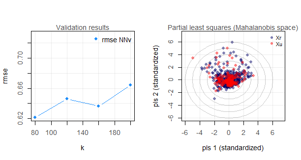

Figure 8.2: MBL results for Total Carbon predictions using the LOCAL algorithm. NNv: nearest-neighbor cross-validation.

```r
plot(local_ciso, main = "")
```

```r
local_ciso
```

```
##
## Call:
##
## mbl(Xr = training$spc_p[!is.na(training$Ciso), ], Yr = training$Ciso[!is.na(training$Ciso)],
##     Xu = testing$spc_p, k = my_ks, method = my_waplsr, diss_method = my_diss,
##     diss_usage = ignore_diss, control = nnv_val_control, scale = TRUE)
##
## _______________________________________________________
##
##  Total number of observations predicted: 207
## _______________________________________________________
##
##  Nearest neighbor validation statistics
##
##      k  rmse st_rmse    r2
## 1:  80 0.621  0.0363 0.874
## 2: 120 0.646  0.0377 0.864
## 3: 160 0.636  0.0371 0.868
## 4: 200 0.664  0.0388 0.859
## _______________________________________________________
```

According to the results obtained in the above example, the neighborhood size that minimizes the root mean squared error (RMSE) in nearest neighbor cross-validation is 80. Let’s get the predictions done for the `testing` dataset:

```r
bki <- which.min(local_ciso$validation_results$nearest_neighbor_validation$rmse)
bk <- local_ciso$validation_results$nearest_neighbor_validation$k[bki]

# all the prediction results are stored in:
local_ciso$results

# the get_predictions function makes easier to retrieve the
# predictions from the previous object
ciso_hat <- as.matrix(get_predictions(local_ciso))[, bki]
```

```r
# Plot predicted vs reference
plot(ciso_hat, testing$Ciso,
     xlim = c(0, 14),
     ylim = c(0, 14),
     xlab = "Predicted Total Carbon, %",
     ylab = "Total Carbon, %",
     main = "LOCAL using argument k")
grid()
abline(0, 1, col = "red")
```

The prediction root mean squared error is then:

```r
# prediction RMSE:
sqrt(mean((ciso_hat - testing$Ciso)^2, na.rm = TRUE))
```

```
## [1] 0.4506581
```

```r
# squared R
cor(ciso_hat, testing$Ciso, use = "complete.obs")^2
```

```
## [1] 0.9155142
```

Similar results are obtained when the optimization of the neighbrhoods is based on distance thresholds:

```r
# create a vector of dissimilarity thresholds to evaluate
# since the correlation dissimilarity will be used
# these thresholds need to be > 0 and <= 1
dths <- seq(0.025, 0.3, by = 0.025)

# indicate the minimum and maximum sizes allowed for the neighborhood
k_min <- 30
k_max <- 200

local_ciso_diss <- mbl(
  Xr = training$spc_p[!is.na(training$Ciso),],
  Yr = training$Ciso[!is.na(training$Ciso)],
  Xu = testing$spc_p,
  k_diss = dths,
  k_range = c(k_min, k_max),
  method = my_waplsr,
  diss_method = my_diss,
  diss_usage = ignore_diss,
  control = nnv_val_control,
  scale = TRUE
)
```

```r
plot(local_ciso_diss)
```

```r
local_ciso_diss
```

```
##
## Call:
##
## mbl(Xr = training$spc_p[!is.na(training$Ciso), ], Yr = training$Ciso[!is.na(training$Ciso)],
##     Xu = testing$spc_p, k_diss = dths, k_range = c(k_min, k_max),
##     method = my_waplsr, diss_method = my_diss, diss_usage = ignore_diss,
##     control = nnv_val_control, scale = TRUE)
##
## _______________________________________________________
##
##  Total number of observations predicted: 207
## _______________________________________________________
##
##  Nearest neighbor validation statistics
##
##     k_diss p_bounded  rmse st_rmse    r2
##  1:  0.025   94.686% 0.611  0.0357 0.878
##  2:  0.050   71.014% 0.613  0.0358 0.877
##  3:  0.075   62.319% 0.620  0.0362 0.874
##  4:  0.100   51.691% 0.610  0.0356 0.879
##  5:  0.125   41.546% 0.588  0.0343 0.887
##  6:  0.150   31.884% 0.537  0.0313 0.906
##  7:  0.175   21.739% 0.571  0.0333 0.894
##  8:  0.200    26.57% 0.615  0.0359 0.877
##  9:  0.225   28.986% 0.595  0.0347 0.884
## 10:  0.250   29.952% 0.628  0.0366 0.871
## 11:  0.275   33.816% 0.618  0.0361 0.875
## 12:  0.300   37.681% 0.625  0.0365 0.873
## _______________________________________________________
```

The best correlation dissimilarity threshold is 0.15. The column “p_bounded” in the table of validation results, indicate the percentage of neighborhoods for which the size was reset either to `k_min` or `k_max`.

```r
# best distance threshold
bdi <- which.min(local_ciso_diss$validation_results$nearest_neighbor_validation$rmse)
bd <- local_ciso_diss$validation_results$nearest_neighbor_validation$k[bdi]

# predictions for the best distance
ciso_diss_hat <- as.matrix(get_predictions(local_ciso_diss))[, bdi]
```

```r
# Plot predicted vs reference
plot(ciso_diss_hat, testing$Ciso,
     xlim = c(0, 14),
     ylim = c(0, 14),
     xlab = "Predicted Total Carbon, %",
     ylab = "Total Carbon, %",
     main = "LOCAL using argument k_diss")
grid()
abline(0, 1, col = "red")
```

## 8.2 Additional examples

Here we provide few additional examples of some MBL configurations where we make use of another response variable available in the dataset: soil cation exchange capacity (CEC). This variable is perhaps more challenging to predict in comparison to Total Carbon. Table 8.1 provides a summary of the configurations tested in the following code examples.

Table 8.1: Basic description of the different MBL configurations in the examples to predict Cation Exhange Capacity (CEC).

| Abreviation | Dissimilarity method | Dissimilarity usage | Local regression |
| --- | --- | --- | --- |
| `local_cec` | Correlation | None | Weighted average PLS |
| `pc_pred_cec` | optimized PC | Source of predictors | Weighted average PLS |
| `pls_pred_cec` | optimized PLS | None | Weighted average PLS |
| `local_gpr_cec` | optimized PC | Source of predictors | Gaussian process |

```r
# Lets define some methods:
my_wapls <- local_fit_wapls(2, 25)
k_min_max <- c(80, 200)

# use the LOCAL algorithm
# specific thresholds for cor dissimilarity
dth_cor <- seq(0.01, 0.3, by = 0.03)
local_cec <- mbl(
  Xr = training$spc_p[!is.na(training$CEC),],
  Yr = training$CEC[!is.na(training$CEC)],
  Xu = testing$spc_p,
  k_diss = dth_cor,
  k_range = k_min_max,
  method = my_wapls,
  diss_method = "cor",
  diss_usage = "none",
  control = nnv_val_control,
  scale = TRUE
)

# use one where pca dissmilarity is used and the dissimilarity matrix
# is used as source of additional predictors
# lets define first a an appropriate vector of dissimilarity thresholds
# for the PC dissimilarity method
dth_pc <- seq(0.05, 1, by = 0.1)
pc_pred_cec <- mbl(
  Xr = training$spc_p[!is.na(training$CEC),],
  Yr = training$CEC[!is.na(training$CEC)],
  Xu = testing$spc_p,
  k_diss = dth_pc,
  k_range = k_min_max,
  method = my_wapls,
  diss_method = "pca",
  diss_usage = "predictors",
  control = nnv_val_control,
  scale = TRUE
)

# use one where PLS dissmilarity is used and the dissimilarity matrix
# is used as source of additional predictors
pls_pred_cec <- mbl(
  Xr = training$spc_p[!is.na(training$CEC),],
  Yr = training$CEC[!is.na(training$CEC)],
  Xu = testing$spc_p,
  Yu = testing$CEC,
  k_diss = dth_pc,
  k_range = k_min_max,
  method = my_wapls,
  diss_method = "pls",
  diss_usage = "none",
  control = nnv_val_control,
  scale = TRUE
)

# use one where Gaussian process regression and pca dissmilarity are used
# and the dissimilarity matrix  is used as source of additional predictors
local_gpr_cec <- mbl(
  Xr = training$spc_p[!is.na(training$CEC),],
  Yr = training$CEC[!is.na(training$CEC)],
  Xu = testing$spc_p,
  k_diss = dth_pc,
  k_range = k_min_max,
  method = local_fit_gpr(),
  diss_method = "pca",
  diss_usage = "predictors",
  control = nnv_val_control,
  scale = TRUE
)
```

Collect the predictions for each configuration:

```r
# get the indices of the best results according to
# nearest neighbor validation statistics
c_val_name <- "validation_results"
c_nn_val_name <- "nearest_neighbor_validation"

bi_local <- which.min(local_cec[[c_val_name]][[c_nn_val_name]]$rmse)
bi_pc_pred <- which.min(pc_pred_cec[[c_val_name]][[c_nn_val_name]]$rmse)
bi_pls_pred <- which.min(pls_pred_cec[[c_val_name]][[c_nn_val_name]]$rmse)
bi_local_gpr  <- which.min(local_gpr_cec[[c_val_name]][[c_nn_val_name]]$rmse)

preds <- cbind(get_predictions(local_cec)[, ..bi_local],
               get_predictions(pc_pred_cec)[, ..bi_pc_pred],
               get_predictions(pls_pred_cec)[, ..bi_pls_pred],
               get_predictions(local_gpr_cec)[, ..bi_local_gpr])

colnames(preds) <- c("local_cec",
                     "pc_pred_cec",
                     "pls_pred_cec",
                     "local_gpr_cec")
preds <- as.matrix(preds)

# R2s
cor(testing$CEC, preds, use = "complete.obs")^2
```

```
##      local_cec pc_pred_cec pls_pred_cec local_gpr_cec
## [1,] 0.7557315   0.7977637      0.77421     0.7790474
```

```r
#RMSEs
colMeans((preds - testing$CEC)^2, na.rm = TRUE)^0.5
```

```
##     local_cec   pc_pred_cec  pls_pred_cec local_gpr_cec
##      3.334444      3.202677      3.299601      3.189961
```

[figure not shown]

Figure 8.3: CEC prediction results for the different MBL configurations tested

```r
old_par <- par("mfrow", "mar")

par(mfrow = c(2, 2))
plot(testing$CEC, preds[, 2],
     xlab = "Predicted CEC, meq/100g",
     ylab = "CEC, meq/100g", main = colnames(preds)[2])
abline(0, 1, col = "red")

plot(testing$CEC, preds[, 3],
     xlab = "Predicted CEC, meq/100g",
     ylab = "CEC, meq/100g", main = colnames(preds)[3])
abline(0, 1, col = "red")

plot(testing$CEC, preds[, 4],
     xlab = "Predicted CEC, meq/100g",
     ylab = "CEC, meq/100g", main = colnames(preds)[4])
abline(0, 1, col = "red")
par(old_par)
```

## 8.3 Using `Yu` argument

If information of the response values in the prediction set is available, then, the `Yu` argument can be used to directly validate the predictions done by `mbl()`. It is not taken into accound for any optimization or modeling step. It can be used as follows:

```r
# use Yu argument to validate the predictions
pc_pred_nt_yu <- mbl(
  Xr = training$spc_p[!is.na(training$Nt),],
  Yr = training$Nt[!is.na(training$Nt)],
  Xu = testing$spc_p,
  Yu = testing$Nt,
  k = seq(40, 100, by = 10),
  diss_usage = "none",
  control = mbl_control(validation_type = "NNv"),
  scale = TRUE
)

pc_pred_nt_yu
```

## 8.4 Supported parallelism

The `mbl()` function uses the `foreach()` function of the [package `foreach`](https://CRAN.R-project.org/package=foreach) for iterating over every row/observation passed to the argument `Xu`. In the following example, we use the [package `doParallel`](https://CRAN.R-project.org/package=doParallel) to set up the cores to be used. Alternatively the [package `doSNOW`](https://CRAN.R-project.org/package=doSNOW) can also be used. In the following example we use parallel processing to predict Total Nitrogen:

```r
# Running the mbl function using multiple cores

# Execute with two cores, if available, ...
n_cores <- 2

# ... if not then go with 1 core
if (parallel::detectCores() < 2) {
  n_cores <- 1
}

# Set the number of cores
library(doParallel)
clust <- makeCluster(n_cores)
registerDoParallel(clust)

# Alternatively:
# library(doSNOW)
# clust <- makeCluster(n_cores, type = "SOCK")
# registerDoSNOW(clust)
# getDoParWorkers()

pc_pred_nt <- mbl(
  Xr = training$spc_p[!is.na(training$Nt),],
  Yr = training$Nt[!is.na(training$Nt)],
  Xu = testing$spc_p,
  k = seq(40, 100, by = 10),
  diss_usage = "none",
  control = mbl_control(validation_type = "NNv"),
  scale = TRUE
)

# go back to sequential processing
registerDoSEQ()
try(stopCluster(clust))

pc_pred_nt
```

# References

Brereton, Richard G. 2003. *Chemometrics: Data Analysis for the Laboratory and Chemical Plant*. John Wiley & Sons.

Chang, C-I. 2000. “An Information-Theoretic Approach to Spectral Variability, Similarity, and Discrimination for Hyperspectral Image Analysis.” *IEEE Transactions on Information Theory* 46 (5): 1927–32.

De Maesschalck, Roy, Delphine Jouan-Rimbaud, and Désiré L Massart. 2000. “The Mahalanobis Distance.” *Chemometrics and Intelligent Laboratory Systems* 50 (1): 1–18.

Kullback, Solomon, and Richard A Leibler. 1951. “On Information and Sufficiency.” *The Annals of Mathematical Statistics* 22 (1): 79–86.

Mitchell, Tom M. 1997. “Machine Learning, Volume 1 of 1.” McGraw-Hill Science/Engineering/-Math.

Naes, Tormod, Tomas Isaksson, and Bruce Kowalski. 1990. “Locally Weighted Regression and Scatter Correction for Near-Infrared Reflectance Data.” *Analytical Chemistry* 62 (7): 664–73.

Pierna, Juan Antonio Fernández, and Pierre Dardenne. 2008. “Soil Parameter Quantification by Nirs as a Chemometric Challenge at ‘Chimiométrie 2006’.” *Chemometrics and Intelligent Laboratory Systems* 91 (1): 94–98.

Ramirez-Lopez, L, T Behrens, K Schmidt, A Stevens, JAM Demattê, and T Scholten. 2013. “The Spectrum-Based Learner: A New Local Approach for Modeling Soil Vis–Nir Spectra of Complex Datasets.” *Geoderma* 195: 268–79.

Ramirez-Lopez, L, T Behrens, K Schmidt, RA Viscarra-Rossel, JAM Demattê, and T Scholten. 2013. “Distance and Similarity-Search Metrics for Use with Soil Vis–Nir Spectra.” *Geoderma* 199: 43–53.

Saul, LK, and ST Roweis. 2003. “Think Globally, Fit Locally: Unsupervised Learning of Low Dimensional Manifolds.” *Journal of Machine Learning Research* 4 (Jun): 119–55.

Savitzky, A, and MJE Golay. 1964. “Smoothing and Differentiation of Data by Simplified Least Squares Procedures.” *Anal. Chem.* 36 (8): 1627–39.

Shenk, John S, Mark O Westerhaus, and Paolo Berzaghi. 1997. “Investigation of a Local Calibration Procedure for Near Infrared Instruments.” *Journal of Near Infrared Spectroscopy* 5 (4): 223–32.

Stevens, Antoine, and Leonardo Ramirez-Lopez. 2020. “An Introduction to the Prospectr Package.” *R Package Vignette, Report No.: R Package Version 0.2.1* 3.

Wold, Herman. 1975. “Soft Modelling by Latent Variables: The Non-Linear Iterative Partial Least Squares (Nipals) Approach.” *Journal of Applied Probability* 12 (S1): 117–42.

Wold, S, H Martens, H Wold, A Ruhe, and B Kagstrom. 1983. “The Multivariate Calibration Method in Chemistry Solved by the Pls Model.” In *Proc. Conf. Matrix Pencils, Lecture Notes in Mathematics*, 286–93. Springer-Verlag Heidelberg.